# Data behind criticisms against Chicago’s School Quality Rating Policy (SQRP)

Aulia Larasati

6/1/2021

```r
# SQRP ratings in 2018-2020
sqrp_rating <- read_excel("sqrp_rating_2018-2020.xlsx",
    sheet = "long_data")  %>% rename(school_year = schoo_year)
```

```r
# racial composition in CPS 2019-2020
race <- read_excel("race_ethnic_2019-2020.xlsx")
```

# School Accountability Status and Rating 2017-2020

Measuring and reporting a school’s quality to parents provides the ability for parents to choose the best school to meet their child’s needs and advocate for improvements. The coexistence between school rating and choice provides the incentives for schools to improve. Based on 2017-2020 data, most elementary schools under Chicago Public Schools are in good standing. The number of schools that need intensive support has also decreased.

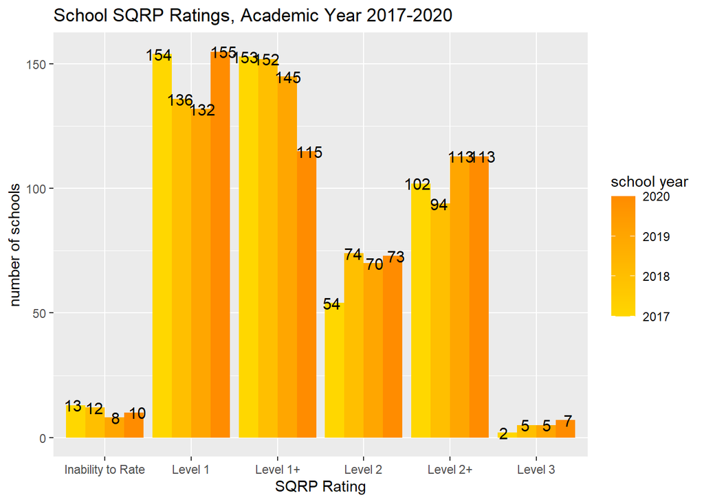

```r
rating_graph <- sqrp_rating %>%
  group_by(school_year, rating) %>%
  summarize(n_school = n()) %>%
  ggplot(aes(x = rating, y = n_school, group = school_year)) +
  geom_col(aes(fill= school_year), position = "dodge") +
  geom_text(aes(x = rating, label = n_school),
            position = position_dodge(width = 1), size = 4) +
  scale_fill_continuous(low = "gold", high = "darkorange") +
  labs(title = "School SQRP Ratings, Academic Year 2017-2020",
       x = "SQRP Rating", fill = "school year", y = "number of schools")
rating_graph
```

When we look more closely at school’s rating annually in the past four years, the number of schools that obtain level 3 ratings has only increased by a handful. However, level 2 schools have increased from 2017 to 2018, and the number has persisted in the past two years.

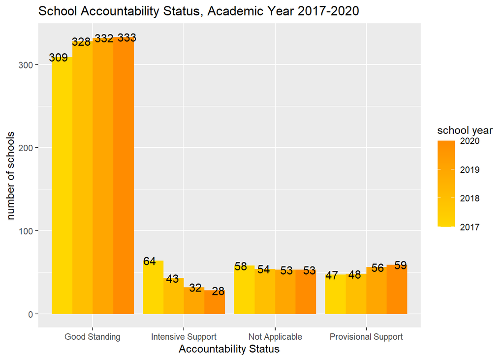

```r
status_graph <- sqrp_rating %>%
  group_by(school_year, status) %>%
  summarize(n_school = n()) %>%
  ggplot(aes(x = status, y = n_school, group = school_year)) +
  geom_col(aes(fill= school_year), position = "dodge") +
  geom_text(aes(x = status, label = n_school),
            position = position_dodge(width = 1), size = 4) +
  scale_fill_continuous(low = "gold", high = "darkorange") +
  labs(title = "School Accountability Status, Academic Year 2017-2020",
       x = "Accountability Status", fill = "school year", y = "number of schools")
status_graph
```

```r
tabel1_ranking <- sqrp_rating %>%
  group_by(school_year, status) %>%
  summarize(n_school = n()) %>%
  pivot_wider(names_from = school_year, values_from = n_school)
tabel1_ranking
```

```
## # A tibble: 4 x 5
##   status              `2017` `2018` `2019` `2020`
##   <chr>                <int>  <int>  <int>  <int>
## 1 Good Standing          309    328    332    333
## 2 Intensive Support       64     43     32     28
## 3 Not Applicable          58     54     53     53
## 4 Provisional Support     47     48     56     59
```